# KoSC K database

Naoise McGarry, Kelly Wyres

30 Oct 26

#load packages

```r
library(tidyverse)
library(readxl)
library(vegan)
library(reshape2)
library(patchwork)
```

# K locus annotations - reported in main text

#### Load data

```r
kosc_summary <- read_csv("KoSC_K_functional_reannotated.csv") # output from gene clustering and HMM searches
```

## Count unique GTs

```r
kosc_summary %>%
  filter(Is_Glycosyl_transferase == TRUE) %>%
  summarise(
    total_GTRs = n(),
    distinct_CC = n_distinct(CC),
  )
```

```
## # A tibble: 1 × 2
##   total_GTRs distinct_CC
##        <int>       <int>
## 1        360         288
```

## GT per locus counts

```r
kosc_summary %>%
  filter(Is_Glycosyl_transferase %in% c("TRUE")) %>%
  group_by(Locus) %>%
  summarise(
    n = n(),
    Locus = paste(unique(Locus), collapse = ", "),
    .groups = "drop"
  )
```

```
## # A tibble: 88 × 2
##    Locus     n
##    <chr> <int>
##  1 KL1       4
##  2 KL10      4
##  3 KL11      4
##  4 KL12      3
##  5 KL13      4
##  6 KL14      4
##  7 KL15      6
##  8 KL16      4
##  9 KL17      6
## 10 KL18      4
## # ℹ 78 more rows
```

## Count *wbaP* ‘PRK15204.1’ / *wcaJ* ‘PRK10124.1’

```r
kosc_summary %>% filter(PGAP_Best %in% c('PRK15204.1', 'PRK10124.1')) %>%
  count(PGAP_Best)
```

```
## # A tibble: 2 × 2
##   PGAP_Best      n
##   <chr>      <int>
## 1 PRK10124.1    11
## 2 PRK15204.1    77
```

## Total number of unique loci with *wzy* annotated

```r
kosc_summary %>%
  filter(Wzy_Best %in% c("WzyA","WzyB","WzyC")) %>%
  summarise(n_loci = n_distinct(Locus))
```

```
## # A tibble: 1 × 1
##   n_loci
##    <int>
## 1     82
```

## Total number of loci with *wzx* annotated

```r
kosc_summary %>%
  filter(Gene_name %in% c("wzx")) %>%
  summarise(total = n())
```

```
## # A tibble: 1 × 1
##   total
##   <int>
## 1    86
```

# Typing stats - reported in main text

#### Load data

```r
tableS3 <- read_excel("Supplementary_Tables.xlsx", sheet = "Supp_Table3")
```

## Final dataset

#### Count total genomes in final dataset

```r
tableS3 %>% group_by(`Included in final dataset? (yes/no)`) %>% summarise(n=n())
```

```
## # A tibble: 2 × 2
##   `Included in final dataset? (yes/no)`     n
##   <chr>                                 <int>
## 1 no                                      344
## 2 yes                                    4055
```

```r
# note NA represets rare species which did not have qualibact QC thresholds, but passed based on empiric criteria
```

#### Filter to final dataset

```r
tableS3 %>% filter(`Included in final dataset? (yes/no)` == "yes") -> final_dataset
```

#### Typing rate KoSC DB for final dataset

```r
final_dataset %>% group_by(KoSC_match_confidence) %>% summarise(n=n())
```

```
## # A tibble: 2 × 2
##   KoSC_match_confidence     n
##   <chr>                 <int>
## 1 Typeable               3981
## 2 Untypeable               74
```

#### Typing rate by genome source

```r
final_dataset %>% filter(Genome_source != "In house") %>% group_by(Genome_source, KoSC_match_confidence) %>% summarise(n=n()) %>% dcast(Genome_source ~ KoSC_match_confidence) -> contigency_table
```

```r
contigency_table %>% mutate(rate = (Typeable / (Typeable + Untypeable)*100))
```

```
##    Genome_source Typeable Untypeable     rate
## 1 AllTheBacteria     2538         42 98.37209
## 2   NCBI GenBank       84          1 98.82353
## 3    NCBI RefSeq      989         27 97.34252
## 4  Pathogenwatch      368          4 98.92473
```

#### pairwise prop test

```r
as.matrix(contigency_table[2:3])
```

```
##      Typeable Untypeable
## [1,]     2538         42
## [2,]       84          1
## [3,]      989         27
## [4,]      368          4
```

```r
pairwise.prop.test(as.matrix(contigency_table[2:3]), p.adjust.method = "bonferroni")
```

```
##
##  Pairwise comparisons using Pairwise comparison of proportions
##
## data:  as.matrix(contigency_table[2:3])
##
##   1    2    3
## 2 1.00 -    -
## 3 0.35 1.00 -
## 4 1.00 1.00 0.71
##
## P value adjustment method: bonferroni
```

#### Supplementary Figure 6 - assembly metrics by source and species

##### No Contigs

```r
final_dataset %>% filter(Species %in% c("K. oxytoca", "K. michiganensis", "K. pasteurii", "K. grimontii")) %>%
  ggplot(aes(x= Genome_source, y = `No. Contigs`, fill = Genome_source)) + geom_boxplot() +
  scale_x_discrete(limits = c("NCBI RefSeq", "NCBI GenBank", "AllTheBacteria", "Pathogenwatch"), labels = c("RS", "GB", "ATB", "PW")) +
  scale_y_continuous(breaks = seq(0, 500, 50)) +
  scale_fill_manual(values= c("#b2df8a", "#a6cee3", "#1f78b4", "#fb9a99")) +
  theme_bw() + theme(axis.text.x = element_text(angle=45, hjust=1)) + guides(fill=FALSE) +
  xlab("Genome Source") +
  facet_wrap(. ~ Species, nrow=1) -> plot_n_contigs
```

##### Genome Length

```r
final_dataset %>% filter(Species %in% c("K. oxytoca", "K. michiganensis", "K. pasteurii", "K. grimontii")) %>%
  ggplot(aes(x= Genome_source, y = `Genome Length`, fill = Genome_source)) + geom_boxplot() +
  scale_x_discrete(limits = c("NCBI RefSeq", "NCBI GenBank", "AllTheBacteria", "Pathogenwatch")) +
  scale_y_continuous(breaks = seq(0, 7000000, 250000), labels = seq(0, 7, 0.25)) +
  scale_fill_manual(values= c("#b2df8a", "#a6cee3", "#1f78b4", "#fb9a99")) +
  theme_bw() + theme(axis.text.x = element_blank(), axis.title.x = element_blank()) +
  guides(fill=FALSE) +
  ylab("Genome Length (Mbp)") +
  facet_wrap(. ~ Species, nrow=1) -> plot_genome_length
```

##### N50

```r
final_dataset %>% filter(Species %in% c("K. oxytoca", "K. michiganensis", "K. pasteurii", "K. grimontii")) %>%
  ggplot(aes(x= Genome_source, y = N50, fill = Genome_source)) + geom_boxplot() +
  scale_x_discrete(limits = c("NCBI RefSeq", "NCBI GenBank", "AllTheBacteria", "Pathogenwatch")) +
  scale_y_continuous(breaks = seq(0, 7000000, 1000000), labels = seq(0, 7, 1)) +
  scale_fill_manual(values= c("#b2df8a", "#a6cee3", "#1f78b4", "#fb9a99")) +
  theme_bw() + theme(axis.text.x = element_blank(), axis.title.x = element_blank()) +
  guides(fill=FALSE) +
  ylab("N50 (Mbp)") +
  facet_wrap(. ~ Species, nrow=1) -> plot_N50
```

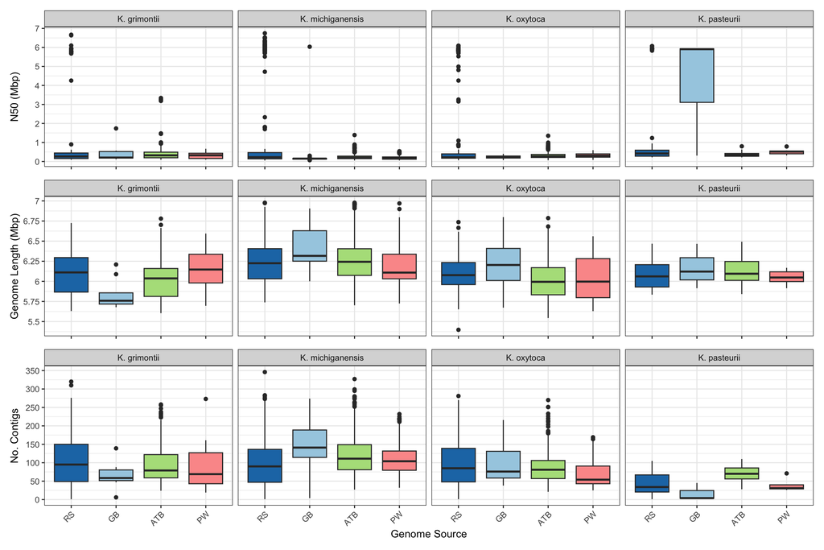

```r
plot_N50 + plot_genome_length + plot_n_contigs + plot_layout(nrow = 3)
```

*Note for the published version of the figure, sample sizes as calculated below were manually added to X-axis labels using Adobe Illustrator.*

#### Get genome counts per column

```r
final_dataset %>% filter(Species %in% c("K. oxytoca", "K. michiganensis", "K. pasteurii", "K. grimontii")) %>% group_by(Genome_source, Species) %>% summarise(n=n())
```

```
## # A tibble: 16 × 3
## # Groups:   Genome_source [4]
##    Genome_source  Species              n
##    <chr>          <chr>            <int>
##  1 AllTheBacteria K. grimontii       425
##  2 AllTheBacteria K. michiganensis  1241
##  3 AllTheBacteria K. oxytoca         831
##  4 AllTheBacteria K. pasteurii        56
##  5 NCBI GenBank   K. grimontii         8
##  6 NCBI GenBank   K. michiganensis    42
##  7 NCBI GenBank   K. oxytoca          31
##  8 NCBI GenBank   K. pasteurii         3
##  9 NCBI RefSeq    K. grimontii       113
## 10 NCBI RefSeq    K. michiganensis   468
## 11 NCBI RefSeq    K. oxytoca         369
## 12 NCBI RefSeq    K. pasteurii        47
## 13 Pathogenwatch  K. grimontii        30
## 14 Pathogenwatch  K. michiganensis   250
## 15 Pathogenwatch  K. oxytoca          87
## 16 Pathogenwatch  K. pasteurii         5
```

## Summarise features captured by non-redundant dataset

#### Filter to non-redundant

```r
final_dataset %>% filter(`Included in nonredundant dataset? (yes/no)` == "yes") -> nonredundant_dataset
```

#### Number distint STs

```r
nonredundant_dataset %>% group_by(ST) %>% summarise(n=n()) %>% nrow()
```

```
## [1] 670
```

#### Counts by country

```r
nonredundant_dataset %>% group_by(Country) %>% summarise(n=n())
```

```
## # A tibble: 66 × 2
##    Country       n
##    <chr>     <int>
##  1 Albania       2
##  2 Argentina     3
##  3 Armenia       1
##  4 Australia   161
##  5 Austria       2
##  6 Belgium       5
##  7 Brazil        6
##  8 Bulgaria      8
##  9 Canada       29
## 10 Chile         2
## # ℹ 56 more rows
```

#### Counts by source

```r
nonredundant_dataset %>% group_by(Isolation_source) %>% summarise(n=n())
```

```
## # A tibble: 5 × 2
##   Isolation_source         n
##   <chr>                <int>
## 1 Animal                  83
## 2 Environment            214
## 3 Hospital Environment    56
## 4 Human                 1113
## 5 NA                     778
```

#### Counts by years

```r
nonredundant_dataset %>% group_by(Collection_year) %>% summarise(n=n()) %>% arrange(Collection_year)
```

```
## # A tibble: 30 × 2
##    Collection_year     n
##    <chr>           <int>
##  1 1886                1
##  2 1900                4
##  3 1958                1
##  4 1974                1
##  5 1997                3
##  6 2001                5
##  7 2002                6
##  8 2003                2
##  9 2004                9
## 10 2005                5
## # ℹ 20 more rows
```

#### Counts by species

```r
nonredundant_dataset %>% group_by(Species) %>% summarise(n=n())
```

```
## # A tibble: 10 × 2
##    Species              n
##    <chr>            <int>
##  1 K. grimontii       348
##  2 K. huaxiensis        8
##  3 K. indica            5
##  4 K. mammalorium       9
##  5 K. michiganensis  1088
##  6 K. oxytoca         689
##  7 K. pasteurii        81
##  8 K. spallanzanii     11
##  9 Taxon 1              4
## 10 Taxon 2              1
```

## Typing rates - nonredundant dataset

#### % typed with KoSC DB

```r
nonredundant_dataset %>%
  count(KoSC_match_confidence) %>%
  mutate(percent = 100 * n / sum(n))
```

```
## # A tibble: 2 × 3
##   KoSC_match_confidence     n percent
##   <chr>                 <int>   <dbl>
## 1 Typeable               2192   97.7
## 2 Untypeable               52    2.32
```

#### % typed with KpSC DB

```r
nonredundant_dataset %>%
  count(Kp_match_confidence) %>%
  mutate(percent = 100 * n / sum(n))
```

```
## # A tibble: 2 × 3
##   Kp_match_confidence     n percent
##   <chr>               <int>   <dbl>
## 1 Typeable             1129    50.3
## 2 Untypeable           1115    49.7
```

#### Statistical comparison KoSC typed vs Kp typed

```r
library(stats)


paired_table <- matrix(c(2193, 1129, 51, 1115), ncol = 2)


mcnemar.test(paired_table)
```

```
##
##  McNemar's Chi-squared test with continuity correction
##
## data:  paired_table
## McNemar's chi-squared = 982.99, df = 1, p-value < 2.2e-16
```

#### n K-loci identified using KoSC db

```r
nonredundant_dataset %>% filter(KoSC_match_confidence == "Typeable") %>% group_by(KoSC_best_match_K_locus) %>% summarise(n=n()) %>% nrow()
```

```
## [1] 88
```

#### n K-loci identified using Kp db

```r
nonredundant_dataset %>% filter(Kp_match_confidence == "Typeable") %>% group_by(Kp_best_match_K_locus) %>% summarise(n=n()) %>% nrow()
```

```
## [1] 22
```

# Typing stats - reported in supplementary text

#### Get match quality info for KoSC db typeables

```r
nonredundant_dataset %>% filter(KoSC_match_confidence == "Typeable") %>% group_by(KoSC_match_problems) %>% summarise(n=n())
```

```
## # A tibble: 65 × 2
##    KoSC_match_problems     n
##    <chr>               <int>
##  1 !                     295
##  2 +!                     10
##  3 -                      65
##  4 -!                      3
##  5 -+                     26
##  6 -+!                     5
##  7 ?10                     2
##  8 ?10+                    1
##  9 ?10-+!                  1
## 10 ?13+!                   3
## # ℹ 55 more rows
```

#### Get match quality info for Kp db typeables

```r
nonredundant_dataset %>% filter(Kp_match_confidence == "Typeable") %>% group_by(Kp_match_problems) %>% summarise(n=n())
```

```
## # A tibble: 63 × 2
##    Kp_match_problems     n
##    <chr>             <int>
##  1 !                    82
##  2 +                    76
##  3 +!                   41
##  4 -                    44
##  5 -!                   20
##  6 -+                   36
##  7 -+!                 324
##  8 ?11                   1
##  9 ?13+                  3
## 10 ?2                   16
## # ℹ 53 more rows
```

#### Format KoSC matches for stats comparison

*remove % characters for ID and cov* *turn into long table with a column labelling by DB*

```r
nonredundant_dataset %>% mutate(KoSC_match_id = (str_remove_all(KoSC_match_id, "%")), KoSC_match_cov = (str_remove_all(KoSC_match_cov, "%"))) %>% select(KoSC_match_confidence, KoSC_match_id, KoSC_match_cov) %>% mutate(database = "KoSC") %>% rename(id = KoSC_match_id, cov = KoSC_match_cov, confidence = KoSC_match_confidence) -> match_comparison
```

#### Format Kp matches for stats comparison

*remove % characters for ID and cov* *turn into long table with a column labelling by DB and bind to above*

```r
nonredundant_dataset %>% mutate(Kp_match_id = (str_remove_all(Kp_match_id, "%")), Kp_match_cov = (str_remove_all(Kp_match_cov, "%"))) %>% select(Kp_match_confidence, Kp_match_id, Kp_match_cov) %>% mutate(database = "Kp") %>% rename(id = Kp_match_id, cov = Kp_match_cov, confidence = Kp_match_confidence) %>% rbind(., match_comparison) -> match_comparison
```

#### Calculate stats for coverage using Wilcox

```r
match_comparison %>% filter (confidence == "Typeable") %>% mutate(cov = as.numeric(cov)) %>%  wilcox.test(cov ~ database, data = .)
```

```
##
##  Wilcoxon rank sum test with continuity correction
##
## data:  cov by database
## W = 1784314, p-value < 2.2e-16
## alternative hypothesis: true location shift is not equal to 0
```

#### Calculate stats for identity using Wilcox

```r
match_comparison %>% filter (confidence == "Typeable") %>% mutate(id = as.numeric(id)) %>%  wilcox.test(id ~ database, data = .)
```

```
##
##  Wilcoxon rank sum test with continuity correction
##
## data:  id by database
## W = 1827748, p-value < 2.2e-16
## alternative hypothesis: true location shift is not equal to 0
```

#### Print average coverage / identity of ‘Typeable’ genomes

```r
match_comparison %>%
  filter(confidence == "Typeable") %>%
  mutate(
    cov   = as.numeric(cov),
    id = as.numeric(id)
  ) %>%
  group_by(database) %>%
  summarise(
    n = n(),
    median_cov = (median(cov, na.rm = TRUE))*100,
    median_id = (median(id, na.rm = TRUE))*100,
    .groups = "drop"
  )
```

```
## # A tibble: 2 × 4
##   database     n median_cov median_id
##   <chr>    <int>      <dbl>     <dbl>
## 1 KoSC      2192      100        99.8
## 2 Kp        1129       96.8      97.0
```

#### Comparing Kp and KoSC results for orthologous loci

*Mark those that are typable with Kp db where the Best match type does not match the KoSC type and is not a direct or similar ortholog as per ortholog list*

```r
nonredundant_dataset %>% mutate(mismatch_types = (if_else(Kp_match_confidence == "Typeable" & (Kp_best_match_K_locus != KoSC_best_match_K_locus), "mismatch", "ok"))) %>%
  mutate(mismatch_types = (if_else(mismatch_types == "mismatch" & Kp_best_match_K_locus == "KL152" & KoSC_best_match_K_locus == "KL10", "ok", mismatch_types))) %>%
  mutate(mismatch_types = (if_else(mismatch_types == "mismatch" & Kp_best_match_K_locus == "KL102" & KoSC_best_match_K_locus == "KL11", "ok", mismatch_types))) %>%
  mutate(mismatch_types = (if_else(mismatch_types == "mismatch" & Kp_best_match_K_locus == "KL181" & KoSC_best_match_K_locus == "KL19", "ok", mismatch_types))) %>%
  mutate(mismatch_types = (if_else(mismatch_types == "mismatch" & Kp_best_match_K_locus == "KL186" & KoSC_best_match_K_locus == "KL23", "ok", mismatch_types))) %>%
  mutate(mismatch_types = (if_else(mismatch_types == "mismatch" & Kp_best_match_K_locus == "KL109" & KoSC_best_match_K_locus == "KL14", "ok", mismatch_types))) %>%
  mutate(mismatch_types = (if_else(mismatch_types == "mismatch" & Kp_best_match_K_locus == "KL47" & KoSC_best_match_K_locus == "KL30", "ok", mismatch_types))) %>%
  mutate(mismatch_types = (if_else(mismatch_types == "mismatch" & Kp_best_match_K_locus == "KL43" & KoSC_best_match_K_locus == "KL6", "ok", mismatch_types))) %>%
  mutate(mismatch_types = (if_else(mismatch_types == "mismatch" & Kp_best_match_K_locus == "KL164" & KoSC_best_match_K_locus == "KL57", "ok", mismatch_types))) %>%
  mutate(mismatch_types = (if_else(mismatch_types == "mismatch" & Kp_best_match_K_locus == "KL68" & KoSC_best_match_K_locus == "KL83", "ok", mismatch_types))) %>%
  mutate(mismatch_types = (if_else(mismatch_types == "mismatch" & Kp_best_match_K_locus == "KL26" & KoSC_best_match_K_locus == "KL9", "ok", mismatch_types))) %>%
  mutate(mismatch_types = (if_else(mismatch_types == "mismatch" & Kp_best_match_K_locus == "KL145" & KoSC_best_match_K_locus == "KL4", "ok", mismatch_types))) %>%
  mutate(mismatch_types = (if_else(mismatch_types == "mismatch" & Kp_best_match_K_locus == "KL174" & KoSC_best_match_K_locus == "KL3", "ok", mismatch_types))) -> nonredundant_dataset
```

#### Count the mismatches

```r
nonredundant_dataset %>% filter(mismatch_types == "mismatch") %>% nrow()
```

```
## [1] 196
```

#### Get match qulaity info for KoSC db matches among the mismatches list

```r
nonredundant_dataset %>% filter(mismatch_types == "mismatch") %>% group_by(KoSC_match_problems) %>% summarise(n=n())
```

```
## # A tibble: 33 × 2
##    KoSC_match_problems     n
##    <chr>               <int>
##  1 !                      20
##  2 +!                      5
##  3 -+!                     2
##  4 ?2                     14
##  5 ?2!                     2
##  6 ?2+!                    1
##  7 ?2-                     4
##  8 ?2-+!                   1
##  9 ?3                      1
## 10 ?3!                     2
## # ℹ 23 more rows
```

#### Get match qulaity info for Kp db matches among the mismatches list

```r
nonredundant_dataset %>% filter(mismatch_types == "mismatch") %>% group_by(Kp_match_problems) %>% summarise(n=n())
```

```
## # A tibble: 24 × 2
##    Kp_match_problems     n
##    <chr>             <int>
##  1 +                     1
##  2 -                    35
##  3 -!                    2
##  4 -+                   15
##  5 -+!                  79
##  6 ?2-                   6
##  7 ?2-!                  1
##  8 ?2-+                  5
##  9 ?2-+!                20
## 10 ?3                    1
## # ℹ 14 more rows
```

#### Count Kp matches with additional genes among mismatches

```r
nonredundant_dataset %>% filter(mismatch_types == "mismatch") %>% filter(str_detect(Kp_match_problems, "\\+")) %>% summarise(n=n())
```

```
## # A tibble: 1 × 1
##       n
##   <int>
## 1   141
```

#### Count Kp matches with missing genes among mismatches

```r
nonredundant_dataset %>% filter(mismatch_types == "mismatch") %>% filter(str_detect(Kp_match_problems, "\\-")) %>% summarise(n=n())
```

```
## # A tibble: 1 × 1
##       n
##   <int>
## 1   194
```

#### Supplementary Figure 7

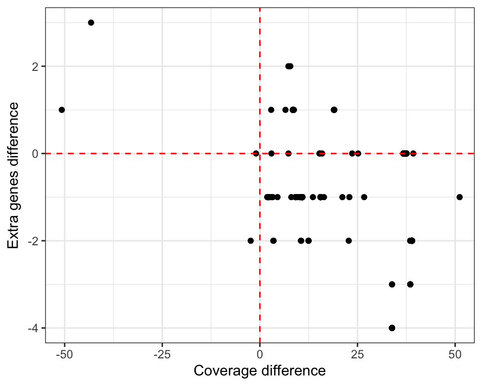

```r
nonredundant_dataset %>%
  filter(mismatch_types == "mismatch") %>%
  mutate(
    KoSC_id = str_remove_all(KoSC_match_id, "%"),
    Kp_id = str_remove_all(Kp_match_id, "%"),
    KoSC_cov = str_remove_all(KoSC_match_cov, "%"),
    Kp_cov = str_remove_all(Kp_match_cov, "%"),
    id_diff = (as.numeric(KoSC_match_id) - as.numeric(Kp_match_id))*100,
    cov_diff = (as.numeric(KoSC_match_cov) - as.numeric(Kp_match_cov))*100,
    extra_genes_diff = KoSC_other_gene_count - Kp_other_genes_count
  ) %>%
  ggplot(aes(x = cov_diff, y = extra_genes_diff)) +
  geom_point() +
  theme_bw() +
  geom_vline(xintercept = 0, linetype = "dashed", colour = "red") +
  geom_hline(yintercept = 0, linetype = "dashed", colour = "red") +
  coord_cartesian(xlim = c(-50, 50), ylim = c(-4, 3)) +
  ylab("Extra genes difference") +
  xlab("Coverage difference")
```